# Linear Regression Lab (3.6)

By [Andrew Mauer-Oats](https://github.com/maueroats).

This work is licensed under a [Creative Commons Attribution-ShareAlike 4.0 International License](https://creativecommons.org/licenses/by-sa/4.0/).

This is a Python-based walkthough of the lab in Section 3.6 of ISL. You should absolutely read the text and consult this document for how to do the same things in Python.

There are several major topics in this lab:

- Linear regression: fitting, prediction, confidence intervals.
- Quality of fit: fitted values, residuals, graphical examination.
- Multiple regression, includes R^2, VIF.
- Regression with cross-terms and powers.
- Minor but important idea: ANOVA to decide which set of predictors to use.
- Regression with categorical / qualitative variables.

The biggest difference between the use of R and Python is that R gives you a quick graphical summary of every regression with just one command. I have not yet written a similar command for Python (but it could be done) (should I?).

```python
# !pip install seaborn==0.9.0
import numpy as np
import pandas as pd
import scipy
import scipy.stats
import matplotlib.pyplot as plt
import seaborn as sns
import statsmodels.api as sm
import statsmodels.formula.api as smf

import warnings
warnings.simplefilter('ignore',FutureWarning)
```

## 3.6.1 Load Libraries

```python
import sklearn.datasets
boston_all = sklearn.datasets.load_boston()
boston = pd.DataFrame(boston_all.data,
                      columns=['crim', 'zn', 'indus', 'chas', 'nox', 'rm', 'age', 'dis', 'rad', 'tax',
                               'ptratio', 'black', 'lstat'])
boston_independent = boston.columns
boston['medv'] = boston_all.target
boston_dependent = ['medv']
```

## 3.6.2a Simple Linear Regression

```python
boston.columns
```

```
Index(['crim', 'zn', 'indus', 'chas', 'nox', 'rm', 'age', 'dis', 'rad', 'tax',
       'ptratio', 'black', 'lstat', 'medv'],
      dtype='object')
```

The `boston_all.DESCR` field contains the description of columns.

```python
#print(boston_all.DESCR) # commented out so I do not see all of the fields every time I run
```

```python
lm_fit = smf.ols('medv ~ lstat', data=boston).fit()
```

In the book they write about "attaching" a data set. As far as I know there is no parallel in Python.

```python
lm_fit.summary()
```

OLS Regression Results

| Dep. Variable: | medv | R-squared: | 0.544 |
| --- | --- | --- | --- |
| Model: | OLS | Adj. R-squared: | 0.543 |
| Method: | Least Squares | F-statistic: | 601.6 |
| Date: | Fri, 05 Oct 2018 | Prob (F-statistic): | 5.08e-88 |
| Time: | 20:01:07 | Log-Likelihood: | -1641.5 |
| No. Observations: | 506 | AIC: | 3287. |
| Df Residuals: | 504 | BIC: | 3295. |
| Df Model: | 1 |  |  |
| Covariance Type: | nonrobust |  |  |

|  | coef | std err | t | P>\|t\| | [0.025 | 0.975] |
| --- | --- | --- | --- | --- | --- | --- |
| Intercept | 34.5538 | 0.563 | 61.415 | 0.000 | 33.448 | 35.659 |
| lstat | -0.9500 | 0.039 | -24.528 | 0.000 | -1.026 | -0.874 |

| Omnibus: | 137.043 | Durbin-Watson: | 0.892 |
| --- | --- | --- | --- |
| Prob(Omnibus): | 0.000 | Jarque-Bera (JB): | 291.373 |
| Skew: | 1.453 | Prob(JB): | 5.36e-64 |
| Kurtosis: | 5.319 | Cond. No. | 29.7 |

Warnings:  
[1] Standard Errors assume that the covariance matrix of the errors is correctly specified.

Notice that the $P>|t|$ column is not in scientific notation,, so $10^{-16}$ renders as $0.000$. (Verify...)

The directory of all possible functions for a fit object is really huge, so I'm not printing it out. The ones with underscores at the start are "internal".

```python
#dir(lm_fit)
```

```python
lm_fit.params
```

```
Intercept    34.553841
lstat        -0.950049
dtype: float64
```

```python
lm_fit.conf_int()
```

|  | 0 | 1 |
| --- | --- | --- |
| Intercept | 33.448457 | 35.659225 |
| lstat | -1.026148 | -0.873951 |

```python
x_for_predict = np.array([5,10,15])
x_df = pd.DataFrame(x_for_predict, columns=["lstat"]);
lm_fit.predict(x_df)
```

```
0    29.803594
1    25.053347
2    20.303101
dtype: float64
```

If you want all of the prediction information, get a prediction data frame. I believe that the `mean_ci` is confidence for the mean, `obs_ci` is the confidence for the prediction. (Please let me know if this information is wrong!)

```python
predict_df = lm_fit.get_prediction(x_df)
predict_df.summary_frame()
```

|  | mean | mean_se | mean_ci_lower | mean_ci_upper | obs_ci_lower | obs_ci_upper |
| --- | --- | --- | --- | --- | --- | --- |
| 0 | 29.803594 | 0.405247 | 29.007412 | 30.599776 | 17.565675 | 42.041513 |
| 1 | 25.053347 | 0.294814 | 24.474132 | 25.632563 | 12.827626 | 37.279068 |
| 2 | 20.303101 | 0.290893 | 19.731588 | 20.874613 | 8.077742 | 32.528459 |

#### Notes on statistics vocabulary

*Population parameter* is a is the "true value" of the underlying trait of the population. Example: average height is a population parameter. You give an estimate of the average height along with a confidence interval.

The term *95% confidence interval* means that if the process were repeated with randomly sampled data, 95% of the resulting intervals would contain the population parameter.

I think this also means that it is 95% likely that the given interval contains the true value of the population parameter.

Warning: the confidence interval gives no information about the distribution of the data. Of course, because a lot of samples will shrink the confidence interval no matter what the distribution.

The *prediction confidence interval* (`obs` in the table above) gives the interval that is 95% likely to contain true value of the prediction. (E.g., based on the known errors for the linear regression formula that you used.)

[Decent explanation](http://statisticsbyjim.com/hypothesis-testing/confidence-prediction-tolerance-intervals/), including *tolerance interval* where you are 95% confident that 99% of the population is within an interval.

Linear model plot - does the regression fitting for you.

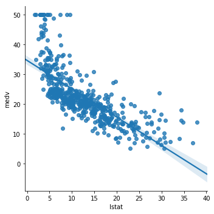

```python
sns.lmplot(x='lstat', y='medv', data=boston);
```

```python
# Joint plot is a little fancier, shows the distributions of each axis as well.
# sns.jointplot(x='lstat', y='medv', kind='reg', data=boston);
```

The lab explains how to draw additional lines of any slope on a graph. If that's what you are doing, you should probably be working directly with Matplotlib instead of Seaborn. If you want different shaped markers, use the `scatterplot` option `markers`.

## 3.6.2b Statistical Summary Plots

### I. Residuals and predicted (or fitted) values

The model predicts a y value for each x value. The predicted y value is called the *fitted value*. There is one predicted y value for each x value in the data set. (Fitted value is $\hat{y}$.)

The difference between a point's y value and the y-value predicted for that point's given x is called the *residual*. (Residual is $y - \hat{y}$.)

Both of these are very commonly used. You should know how to get them out of the linear model (`fittedvalues` and `resid`).

#### Option 1: Full Seaborn

Seaborn will just do the regression and everything for you.

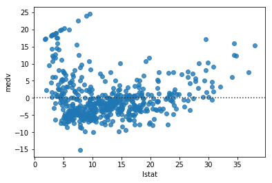

```python
sns.residplot(x='lstat', y='medv', data=boston);
```

#### Option 2: Linear Model

Use fitted values and residuals from the linear model (created by `ols` at the very start of this document).

```python
x_predict = lm_fit.fittedvalues
y_residuals = lm_fit.resid
```

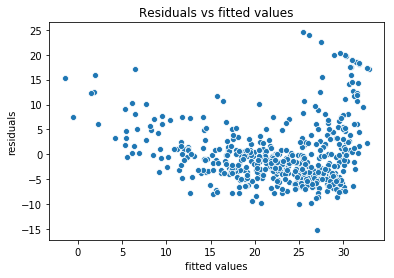

```python
fig, ax = plt.subplots()
fig = sns.scatterplot(lm_fit.fittedvalues, lm_fit.resid);
ax.set_ylabel("residuals");
ax.set_xlabel("fitted values");
ax.set_title("Residuals vs fitted values");
```

### II Q-Q plot (Quantile-Quantile)

The idea behind a Q-Q plot is to show the quantiles of a normal distribution vs quantiles of the errors. I guess if the errors are normally distributed and the model is perfect, you see a straight line.

The Q-Q plot is supposed to show how close your data is to a normal distribution? (Or approximately - student t-dist?) This data below shows a terrible fit for the model given - percent lower status families is not linearly related to median value of the homes.

#### Best Option: StatsModels ProbPlot

Just use the StatsModels `qqplot` function.

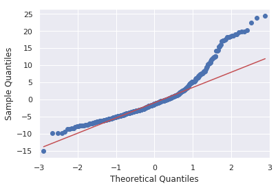

```python
sm.qqplot(y_residuals,line='q');
```

### Scale-Location Plot

Just look this one up if you ever need to scan for "heteroskedacity".... or copy the code / plot from the end.

### Leverage Plot

What is leverage?

The assumption in working with the data is that the errors at every observation are independent and have the same variance. However, when you make a linear regression through the data, the variance of the errors at each point are *not* the same.

Maybe we can do the math and maybe not.

Fact for now: $\hat{y} = Hx$ ($H$ is the "hat matrix" which gives the result of the linear regression.) The diagonal entries of the matrix, $h_{ii}$, tell how the variance of the error at observation i relates to the variance of the actual errors. Var(error at observation i) = (true variance of error)$\times (1-h_{ii})$.

*Studentized residuals* means compensate for the differing variance of the errors at each point by dividing by $\sigma \sqrt(1-h_{ii})$.

Influence plot = studentized residuals vs leverage. The influence plot is supposed to show you if the residuals are behaving as expected (say more...)... how much each point is influencing the resulting regression.

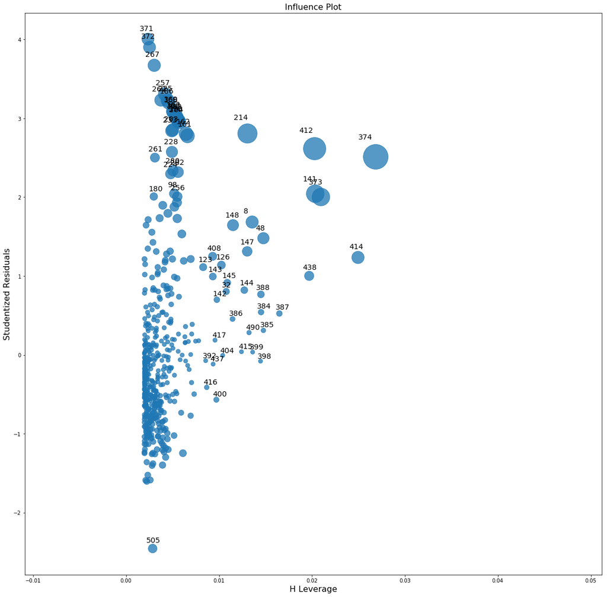

```python
fig, ax = plt.subplots(figsize=(20,20))
fig = sm.graphics.influence_plot(lm_fit, ax=ax)
plt.show()
```

## 3.6.3 Multiple Linear Regression

```python
lm_multiple = smf.ols('medv ~ lstat + age', data=boston).fit()
lm_multiple.summary()
```

OLS Regression Results

| Dep. Variable: | medv | R-squared: | 0.551 |
| --- | --- | --- | --- |
| Model: | OLS | Adj. R-squared: | 0.549 |
| Method: | Least Squares | F-statistic: | 309.0 |
| Date: | Fri, 05 Oct 2018 | Prob (F-statistic): | 2.98e-88 |
| Time: | 21:02:10 | Log-Likelihood: | -1637.5 |
| No. Observations: | 506 | AIC: | 3281. |
| Df Residuals: | 503 | BIC: | 3294. |
| Df Model: | 2 |  |  |
| Covariance Type: | nonrobust |  |  |

|  | coef | std err | t | P>\|t\| | [0.025 | 0.975] |
| --- | --- | --- | --- | --- | --- | --- |
| Intercept | 33.2228 | 0.731 | 45.458 | 0.000 | 31.787 | 34.659 |
| lstat | -1.0321 | 0.048 | -21.416 | 0.000 | -1.127 | -0.937 |
| age | 0.0345 | 0.012 | 2.826 | 0.005 | 0.011 | 0.059 |

| Omnibus: | 124.288 | Durbin-Watson: | 0.945 |
| --- | --- | --- | --- |
| Prob(Omnibus): | 0.000 | Jarque-Bera (JB): | 244.026 |
| Skew: | 1.362 | Prob(JB): | 1.02e-53 |
| Kurtosis: | 5.038 | Cond. No. | 201. |

Warnings:  
[1] Standard Errors assume that the covariance matrix of the errors is correctly specified.

When you want to use all of the predictors in your model, I like two choices:

1. Separate the dependent ($X$) and independent ($y$) variables, and use the basic `sm.ols` method.
2. Make a formula by joining all of the variables you are interested in together into a string.

Info: To eliminiate a few of the variables, append subtractions to the formula, like "-dis-rad". The subtractions will override the additions in the formula.

```python
multiple_formula_rhs = "+".join(boston_independent)
multiple_formula_rhs
```

```
'crim+zn+indus+chas+nox+rm+age+dis+rad+tax+ptratio+black+lstat'
```

```python
lm_multiple = smf.ols('medv ~ ' + multiple_formula_rhs, data=boston).fit()
lm_multiple.summary()
```

OLS Regression Results

| Dep. Variable: | medv | R-squared: | 0.741 |
| --- | --- | --- | --- |
| Model: | OLS | Adj. R-squared: | 0.734 |
| Method: | Least Squares | F-statistic: | 108.1 |
| Date: | Fri, 05 Oct 2018 | Prob (F-statistic): | 6.95e-135 |
| Time: | 22:51:25 | Log-Likelihood: | -1498.8 |
| No. Observations: | 506 | AIC: | 3026. |
| Df Residuals: | 492 | BIC: | 3085. |
| Df Model: | 13 |  |  |
| Covariance Type: | nonrobust |  |  |

|  | coef | std err | t | P>\|t\| | [0.025 | 0.975] |
| --- | --- | --- | --- | --- | --- | --- |
| Intercept | 36.4911 | 5.104 | 7.149 | 0.000 | 26.462 | 46.520 |
| crim | -0.1072 | 0.033 | -3.276 | 0.001 | -0.171 | -0.043 |
| zn | 0.0464 | 0.014 | 3.380 | 0.001 | 0.019 | 0.073 |
| indus | 0.0209 | 0.061 | 0.339 | 0.735 | -0.100 | 0.142 |
| chas | 2.6886 | 0.862 | 3.120 | 0.002 | 0.996 | 4.381 |
| nox | -17.7958 | 3.821 | -4.658 | 0.000 | -25.302 | -10.289 |
| rm | 3.8048 | 0.418 | 9.102 | 0.000 | 2.983 | 4.626 |
| age | 0.0008 | 0.013 | 0.057 | 0.955 | -0.025 | 0.027 |
| dis | -1.4758 | 0.199 | -7.398 | 0.000 | -1.868 | -1.084 |
| rad | 0.3057 | 0.066 | 4.608 | 0.000 | 0.175 | 0.436 |
| tax | -0.0123 | 0.004 | -3.278 | 0.001 | -0.020 | -0.005 |
| ptratio | -0.9535 | 0.131 | -7.287 | 0.000 | -1.211 | -0.696 |
| black | 0.0094 | 0.003 | 3.500 | 0.001 | 0.004 | 0.015 |
| lstat | -0.5255 | 0.051 | -10.366 | 0.000 | -0.625 | -0.426 |

| Omnibus: | 178.029 | Durbin-Watson: | 1.078 |
| --- | --- | --- | --- |
| Prob(Omnibus): | 0.000 | Jarque-Bera (JB): | 782.015 |
| Skew: | 1.521 | Prob(JB): | 1.54e-170 |
| Kurtosis: | 8.276 | Cond. No. | 1.51e+04 |

Warnings:  
[1] Standard Errors assume that the covariance matrix of the errors is correctly specified.  
[2] The condition number is large, 1.51e+04. This might indicate that there are  
strong multicollinearity or other numerical problems.

```python
lm_multiple.rsquared
```

```
0.7406077428649428
```

The book mentions a sequence of error estimators that can be used to select a good number of explanatory variables to use.

- AIC
- BIC
- Adjusted $R^2$
- $C_p$: Not included in the OLS results.

We will learn more about them in Chapter 6.

```python
print(lm_multiple.aic)
print(lm_multiple.bic)
print(lm_multiple.rsquared_adj)
```

```
3025.6767200074596
3084.848233377484
0.7337538824121872
```

Mean squared error of the residuals = sum of squares divided by "residual degrees of freedom". Note that this is not MSE from the text (where you always divide by the number of observations).

```python
lm_multiple.mse_resid
```

```
22.52088675640218
```

The text mentions $VIF$, the variance inflation factor.

```python
from statsmodels.stats.outliers_influence import variance_inflation_factor as vif

vif(boston[boston_independent].values,1)
```

```
2.8438903527570782
```

**DANGER**: Mistake mistake mistake!! Keep reading.

```python
# WRONG WAY!! DO NOT COPY!!
vif_data = [vif(boston[boston_independent].dropna().values, idx) for idx in range(len(boston_independent))]
vif_df = pd.DataFrame(vif_data, index = boston_independent)
vif_df = vif_df.transpose()
# i did not have any luck changing to making columns
vif_df
```

|  | crim | zn | indus | chas | nox | rm | age | dis | rad | tax | ptratio | black | lstat |
| --- | --- | --- | --- | --- | --- | --- | --- | --- | --- | --- | --- | --- | --- |
| 0 | 2.074626 | 2.84389 | 14.484283 | 1.152891 | 73.902212 | 77.934969 | 21.386774 | 14.699368 | 15.154742 | 61.226929 | 85.027314 | 20.066007 | 11.088865 |

If you look you will see the numbers do not agree with the ones from the R package... I am assuming the method used is slightly different. The value for `indus` and `nox` are really different... better check on this.

**Solution**: The "design matrix" needs to include a constant term. This would have been done automatically if we were using a design matrix generator like the `statsmodels.formula` API (which uses the `patsy` package internally). Lots of gotchas!

**TODO**: Revise this section so you generate the formulas through the API.

```python
bconstant = boston.copy()
bconstant['constant'] = 1
bc_indices = boston_independent.append(pd.Index(['constant']))
vif_data = [vif(bconstant[bc_indices].dropna().values, idx) for idx in range(len(bc_indices))]
vif_df = pd.DataFrame([vif_data], columns = bc_indices)
# Notice the list of lists as input so the list is understood as one row of an Nx1 matrix
vif_df
```

|  | crim | zn | indus | chas | nox | rm | age | dis | rad | tax | ptratio | black | lstat | constant |
| --- | --- | --- | --- | --- | --- | --- | --- | --- | --- | --- | --- | --- | --- | --- |
| 0 | 1.773321 | 2.298641 | 3.991194 | 1.073943 | 4.395064 | 1.934161 | 3.10086 | 3.956551 | 7.480539 | 9.008472 | 1.79922 | 1.345832 | 2.938127 | 585.42521 |

R has an "update" function that lets you modify the formula but keep the same other inputs to a regression. That does not seem like an important feature, and it does not make sense the way StatsModels works, so just run the regression again!

## 3.6.4 Interaction Terms

```python
smf.ols('medv ~ lstat * age', data=boston).fit().summary()
```

OLS Regression Results

| Dep. Variable: | medv | R-squared: | 0.556 |
| --- | --- | --- | --- |
| Model: | OLS | Adj. R-squared: | 0.553 |
| Method: | Least Squares | F-statistic: | 209.3 |
| Date: | Sat, 06 Oct 2018 | Prob (F-statistic): | 4.86e-88 |
| Time: | 08:37:21 | Log-Likelihood: | -1635.0 |
| No. Observations: | 506 | AIC: | 3278. |
| Df Residuals: | 502 | BIC: | 3295. |
| Df Model: | 3 |  |  |
| Covariance Type: | nonrobust |  |  |

|  | coef | std err | t | P>\|t\| | [0.025 | 0.975] |
| --- | --- | --- | --- | --- | --- | --- |
| Intercept | 36.0885 | 1.470 | 24.553 | 0.000 | 33.201 | 38.976 |
| lstat | -1.3921 | 0.167 | -8.313 | 0.000 | -1.721 | -1.063 |
| age | -0.0007 | 0.020 | -0.036 | 0.971 | -0.040 | 0.038 |
| lstat:age | 0.0042 | 0.002 | 2.244 | 0.025 | 0.001 | 0.008 |

| Omnibus: | 135.601 | Durbin-Watson: | 0.965 |
| --- | --- | --- | --- |
| Prob(Omnibus): | 0.000 | Jarque-Bera (JB): | 296.955 |
| Skew: | 1.417 | Prob(JB): | 3.29e-65 |
| Kurtosis: | 5.461 | Cond. No. | 6.88e+03 |

Warnings:  
[1] Standard Errors assume that the covariance matrix of the errors is correctly specified.  
[2] The condition number is large, 6.88e+03. This might indicate that there are  
strong multicollinearity or other numerical problems.

## 3.6.5 Non-linear transformations of the predictors

StatsModels, you get the second power of `lstat` in a regression by writing `I(lstat**2)`.

R-compatible behavior in StatsModels/patsy is **unexpected and hence annoying**. Patsy says it supports `**` as the exponentiation operator, but [it's complicated](https://stackoverflow.com/questions/32484244/reciprocals-in-patsy/36539093#36539093). Really you can (need to!) write almost exactly the same kind of formula as in R, including the `I`, so `I(var**2)`. Except that in R you write `I(var^2)` ... ugh.

- Do use `I(var**power)` for exponential.
- Do not use `^` that is bitwise or.
- You do not automatically get lower powers! (See below for polynomials.)

```python
lm_fit2 = smf.ols('medv ~ 1 + lstat + I(lstat**2)', data=boston).fit()
lm_fit2.summary()
```

OLS Regression Results

| Dep. Variable: | medv | R-squared: | 0.641 |
| --- | --- | --- | --- |
| Model: | OLS | Adj. R-squared: | 0.639 |
| Method: | Least Squares | F-statistic: | 448.5 |
| Date: | Sat, 06 Oct 2018 | Prob (F-statistic): | 1.56e-112 |
| Time: | 09:00:54 | Log-Likelihood: | -1581.3 |
| No. Observations: | 506 | AIC: | 3169. |
| Df Residuals: | 503 | BIC: | 3181. |
| Df Model: | 2 |  |  |
| Covariance Type: | nonrobust |  |  |

|  | coef | std err | t | P>\|t\| | [0.025 | 0.975] |
| --- | --- | --- | --- | --- | --- | --- |
| Intercept | 42.8620 | 0.872 | 49.149 | 0.000 | 41.149 | 44.575 |
| lstat | -2.3328 | 0.124 | -18.843 | 0.000 | -2.576 | -2.090 |
| I(lstat ** 2) | 0.0435 | 0.004 | 11.628 | 0.000 | 0.036 | 0.051 |

| Omnibus: | 107.006 | Durbin-Watson: | 0.921 |
| --- | --- | --- | --- |
| Prob(Omnibus): | 0.000 | Jarque-Bera (JB): | 228.388 |
| Skew: | 1.128 | Prob(JB): | 2.55e-50 |
| Kurtosis: | 5.397 | Cond. No. | 1.13e+03 |

Warnings:  
[1] Standard Errors assume that the covariance matrix of the errors is correctly specified.  
[2] The condition number is large, 1.13e+03. This might indicate that there are  
strong multicollinearity or other numerical problems.

Analysis of variance performs statistical testing to quantify how much better the second model is than the first one. (Etc, works with more models.) You could spend quite a bit of time reading about how this works if you wanted to.

Analysis of variance technical note: give the models in order of increasing complexity. Not symmetric! The warnings you see are fine - where you see NaN in the table, R just leaves blanks.

```python
lm_fit = smf.ols('medv ~ lstat', data=boston).fit()
sm.stats.anova_lm(lm_fit, lm_fit2)
```

[output not shown]

|  | df_resid | ssr | df_diff | ss_diff | F | Pr(>F) |
| --- | --- | --- | --- | --- | --- | --- |
| 0 | 504.0 | 19472.381418 | 0.0 | NaN | NaN | NaN |
| 1 | 503.0 | 15347.243158 | 1.0 | 4125.13826 | 135.199822 | 7.630116e-28 |

Read the book - a probability of $10^{-28}$ means it is virtually certain that the quadratic model is better than the linear one.

There is no `poly` function in StatsModels / patsy, and you can not cheat by exponentiating `(1 + var)`, so write one yourself.

```python
def patsy_poly(var,n):
    """Return a string: var+I(var**2)+I(var**3)+...+I(var**n)."""
    if n == 0:
        return "1" # should be "1"?
    elif n==1:
        return var
    else:
        return  patsy_poly(var,n-1) + "+I({}**{})".format(var,n)
```

```python
#import patsy
#patsy.dmatrix('~' + patsy_poly('lstat',3), boston)
```

```python
smf.ols("medv ~ " + patsy_poly('lstat',5), data=boston).fit().summary()
```

OLS Regression Results

| Dep. Variable: | medv | R-squared: | 0.682 |
| --- | --- | --- | --- |
| Model: | OLS | Adj. R-squared: | 0.679 |
| Method: | Least Squares | F-statistic: | 214.2 |
| Date: | Sat, 06 Oct 2018 | Prob (F-statistic): | 8.73e-122 |
| Time: | 09:22:13 | Log-Likelihood: | -1550.6 |
| No. Observations: | 506 | AIC: | 3113. |
| Df Residuals: | 500 | BIC: | 3139. |
| Df Model: | 5 |  |  |
| Covariance Type: | nonrobust |  |  |

|  | coef | std err | t | P>\|t\| | [0.025 | 0.975] |
| --- | --- | --- | --- | --- | --- | --- |
| Intercept | 67.6997 | 3.604 | 18.783 | 0.000 | 60.618 | 74.781 |
| lstat | -11.9911 | 1.526 | -7.859 | 0.000 | -14.989 | -8.994 |
| I(lstat ** 2) | 1.2728 | 0.223 | 5.703 | 0.000 | 0.834 | 1.711 |
| I(lstat ** 3) | -0.0683 | 0.014 | -4.747 | 0.000 | -0.097 | -0.040 |
| I(lstat ** 4) | 0.0017 | 0.000 | 4.143 | 0.000 | 0.001 | 0.003 |
| I(lstat ** 5) | -1.632e-05 | 4.42e-06 | -3.692 | 0.000 | -2.5e-05 | -7.63e-06 |

| Omnibus: | 144.085 | Durbin-Watson: | 0.987 |
| --- | --- | --- | --- |
| Prob(Omnibus): | 0.000 | Jarque-Bera (JB): | 494.545 |
| Skew: | 1.292 | Prob(JB): | 4.08e-108 |
| Kurtosis: | 7.096 | Cond. No. | 1.37e+08 |

Warnings:  
[1] Standard Errors assume that the covariance matrix of the errors is correctly specified.  
[2] The condition number is large, 1.37e+08. This might indicate that there are  
strong multicollinearity or other numerical problems.

Let's use anova to analyze a sequence of models where you keep adding powers of lstat, polynomials from degree 1 to 7.

```python
manymodels = \
[ smf.ols("medv ~ " + patsy_poly('lstat',k), data=boston).fit()
  for k in range(8) ]
sm.stats.anova_lm(*manymodels)
```

|  | df_resid | ssr | df_diff | ss_diff | F | Pr(>F) |
| --- | --- | --- | --- | --- | --- | --- |
| 0 | 505.0 | 42716.295415 | 0.0 | NaN | NaN | NaN |
| 1 | 504.0 | 19472.381418 | 1.0 | 23243.913997 | 854.221354 | 1.427644e-110 |
| 2 | 503.0 | 15347.243158 | 1.0 | 4125.138260 | 151.600165 | 1.236308e-30 |
| 3 | 502.0 | 14615.481262 | 1.0 | 731.761897 | 26.892486 | 3.124916e-07 |
| 4 | 501.0 | 13967.690615 | 1.0 | 647.790646 | 23.806516 | 1.433576e-06 |
| 5 | 500.0 | 13597.035027 | 1.0 | 370.655588 | 13.621713 | 2.481525e-04 |
| 6 | 499.0 | 13554.671158 | 1.0 | 42.363869 | 1.556886 | 2.127070e-01 |
| 7 | 498.0 | 13550.901204 | 1.0 | 3.769954 | 0.138547 | 7.098881e-01 |

Notice that the likelihood that model 6 (which is a degree 6 polynomial) is not a significant improvement on the degree five polynomnial (chance of the results being better (if they are) by chance is 20%).

## 3.6.6 Qualitative Predictors

[Car seats dataset documentation](http://vincentarelbundock.github.io/Rdatasets/doc/ISLR/Carseats.html).

```python
carseats = pd.read_csv('http://vincentarelbundock.github.io/Rdatasets/csv/ISLR/Carseats.csv');
carseats.drop(columns='Unnamed: 0', inplace=True);
```

```python
carseats.head()
```

|  | Sales | CompPrice | Income | Advertising | Population | Price | ShelveLoc | Age | Education | Urban | US |
| --- | --- | --- | --- | --- | --- | --- | --- | --- | --- | --- | --- |
| 0 | 9.50 | 138 | 73 | 11 | 276 | 120 | Bad | 42 | 17 | Yes | Yes |
| 1 | 11.22 | 111 | 48 | 16 | 260 | 83 | Good | 65 | 10 | Yes | Yes |
| 2 | 10.06 | 113 | 35 | 10 | 269 | 80 | Medium | 59 | 12 | Yes | Yes |
| 3 | 7.40 | 117 | 100 | 4 | 466 | 97 | Medium | 55 | 14 | Yes | Yes |
| 4 | 4.15 | 141 | 64 | 3 | 340 | 128 | Bad | 38 | 13 | Yes | No |

```python
carseats_independent = set(carseats.columns) - set(['Sales'])
carseats_dot = '+'.join(carseats_independent)
```

```python
carseats.drop(columns='Unnamed: 0').head()
```

|  | Sales | CompPrice | Income | Advertising | Population | Price | ShelveLoc | Age | Education | Urban | US |
| --- | --- | --- | --- | --- | --- | --- | --- | --- | --- | --- | --- |
| 0 | 9.50 | 138 | 73 | 11 | 276 | 120 | Bad | 42 | 17 | Yes | Yes |
| 1 | 11.22 | 111 | 48 | 16 | 260 | 83 | Good | 65 | 10 | Yes | Yes |
| 2 | 10.06 | 113 | 35 | 10 | 269 | 80 | Medium | 59 | 12 | Yes | Yes |
| 3 | 7.40 | 117 | 100 | 4 | 466 | 97 | Medium | 55 | 14 | Yes | Yes |
| 4 | 4.15 | 141 | 64 | 3 | 340 | 128 | Bad | 38 | 13 | Yes | No |

```python
smf.ols( 'Sales ~ ' + carseats_dot + " + Income:Advertising + Price:Age", data=carseats).fit().summary()
```

OLS Regression Results

| Dep. Variable: | Sales | R-squared: | 0.876 |
| --- | --- | --- | --- |
| Model: | OLS | Adj. R-squared: | 0.872 |
| Method: | Least Squares | F-statistic: | 210.0 |
| Date: | Sat, 06 Oct 2018 | Prob (F-statistic): | 6.14e-166 |
| Time: | 09:39:31 | Log-Likelihood: | -564.67 |
| No. Observations: | 400 | AIC: | 1157. |
| Df Residuals: | 386 | BIC: | 1213. |
| Df Model: | 13 |  |  |
| Covariance Type: | nonrobust |  |  |

|  | coef | std err | t | P>\|t\| | [0.025 | 0.975] |
| --- | --- | --- | --- | --- | --- | --- |
| Intercept | 6.5756 | 1.009 | 6.519 | 0.000 | 4.592 | 8.559 |
| Urban[T.Yes] | 0.1402 | 0.112 | 1.247 | 0.213 | -0.081 | 0.361 |
| US[T.Yes] | -0.1576 | 0.149 | -1.058 | 0.291 | -0.450 | 0.135 |
| ShelveLoc[T.Good] | 4.8487 | 0.153 | 31.724 | 0.000 | 4.548 | 5.149 |
| ShelveLoc[T.Medium] | 1.9533 | 0.126 | 15.531 | 0.000 | 1.706 | 2.201 |
| CompPrice | 0.0929 | 0.004 | 22.567 | 0.000 | 0.085 | 0.101 |
| Income | 0.0109 | 0.003 | 4.183 | 0.000 | 0.006 | 0.016 |
| Education | -0.0209 | 0.020 | -1.063 | 0.288 | -0.059 | 0.018 |
| Advertising | 0.0702 | 0.023 | 3.107 | 0.002 | 0.026 | 0.115 |
| Population | 0.0002 | 0.000 | 0.433 | 0.665 | -0.001 | 0.001 |
| Price | -0.1008 | 0.007 | -13.549 | 0.000 | -0.115 | -0.086 |
| Age | -0.0579 | 0.016 | -3.633 | 0.000 | -0.089 | -0.027 |
| Income:Advertising | 0.0008 | 0.000 | 2.698 | 0.007 | 0.000 | 0.001 |
| Price:Age | 0.0001 | 0.000 | 0.801 | 0.424 | -0.000 | 0.000 |

| Omnibus: | 1.281 | Durbin-Watson: | 2.047 |
| --- | --- | --- | --- |
| Prob(Omnibus): | 0.527 | Jarque-Bera (JB): | 1.147 |
| Skew: | 0.129 | Prob(JB): | 0.564 |
| Kurtosis: | 3.050 | Cond. No. | 1.31e+05 |

Warnings:  
[1] Standard Errors assume that the covariance matrix of the errors is correctly specified.  
[2] The condition number is large, 1.31e+05. This might indicate that there are  
strong multicollinearity or other numerical problems.

Categorical variables have only a few values. They are encoded as boolean variables. (See book.)

The `contrasts` from R are the variables like "`ShelveLoc[T.Good]`". I read this one as "ShelveLoc True (1) means Good".

## 3.6.7 Writing Functions

This guide is written on the assumption that you have some basic knowledge of programming in Python. That means you already know how to write functions.

## Notes

### Hat Matrix

It would make sense to me to keep the hat matrix after any linear regression.

- leverage of each point ($h_{ii}$)
- "externally studentized" meaning estimate standard deviation without the point in question ([Wikipedia notes](https://en.wikipedia.org/wiki/Studentized_residual))

### Data sources

[Datasets distributed with R](https://vincentarelbundock.github.io/Rdatasets/) is a collection of data placed on github by a U of M professor. We will get our data from there from now on!

## Appendix: R-style regression summary plots

Need to produce four plots:

1. Residuals vs Fitted values with lowess
2. QQ standardized residuals vs normal residuals with best fit (?) line
3. Sqrt(abs(standardized residual)) vs fitted values
4. Standardized residuals vs leverage w/ lowess? and cook's distance

This should mostly be a copy of Emre Can's [GSOC project to make R graphs in Python](http://emredjan.github.io/blog/2017/07/11/emulating-r-plots-in-python/).

```python
def plot_add_label(ax, xlabel=None, ylabel=None, title=None):
    if ax == None: return ax
    if xlabel: ax.set_xlabel(xlabel);
    if ylabel: ax.set_ylabel(ylabel);
    if title: ax.set_title(title);
    return ax

def plot_add_lowess(x, y, ax, color='red'):
    if ax == None: raise RuntimeException('Lowess needs axes to work with!')
    smooth_data = sm.nonparametric.lowess(endog=y, exog=x)
    fig = sns.lineplot(x=smooth_data[:,0], y=smooth_data[:,1], color=color, ax=ax)
    return fig

def plot_1_resid_vs_fitted(lm_fit,
                           ax = None,
                           xlabel="fitted values",
                           ylabel="residuals",
                           title="Residuals vs fitted values"):
    if ax == None: ax = plt.gca()
    x = lm_fit.fittedvalues
    y = lm_fit.resid
    fig = sns.scatterplot(x=x, y=y, ax=ax);
    xrange = ax.get_xlim()
    zeros = np.zeros(2)
    sns.lineplot(xrange, zeros, color='gray', style = zeros, dashes=[[2,4]], legend=False, ax=ax);
    plot_add_lowess(x,y,ax)
    plot_add_label(ax, xlabel=xlabel, ylabel=ylabel, title=title)
    return fig
```

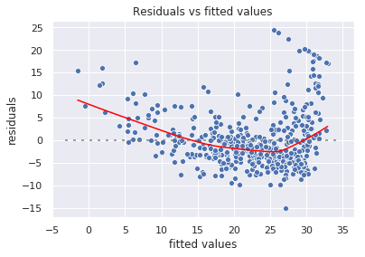

```python
plot_1_resid_vs_fitted(lm_fit);
```

```python
def plot_2_residuals_vs_normal (lm_fit,
                                ax = None,
                                xlabel="Theoretical Quantiles",
                                ylabel="Standardized Residuals",
                                title="Normal Q-Q"):
    y_residuals = lm_fit.get_influence().resid_studentized_internal
    if ax == None: ax = plt.gca()
    fig = sm.qqplot(y_residuals, line='q', ax=ax)
    plot_add_label(ax, xlabel=xlabel, ylabel=ylabel, title=title)
    return fig
```

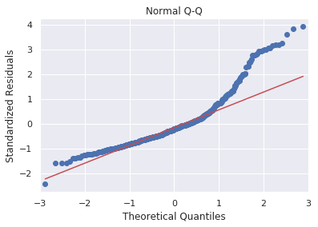

```python
plot_2_residuals_vs_normal(lm_fit);
```

```python
def plot_3_std_resid_vs_fitted(lm_fit,
                               ax = None,
                               xlabel="fitted values",
                               ylabel="$\sqrt{|{Standardized residuals}|}$",
                               title="Scale-Location"):
    if ax == None: ax = plt.gca()
    x = lm_fit.fittedvalues
    y = lm_fit.get_influence().resid_studentized_internal
    fig = sns.scatterplot(x=x, y=y, ax=ax)
    plot_add_lowess(x, y, ax)
    plot_add_label(ax, xlabel=xlabel, ylabel=ylabel, title=title)
    return fig
```

[figure not shown]

```python
plot_3_std_resid_vs_fitted(lm_fit);
```

```python
def plot_4_std_resid_vs_leverage(lm_fit,
                                 ax = None,
                                 xlabel="Leverage",
                                 ylabel="Standardized residuals",
                                 title="Residuals vs Leverage"):
    if ax == None: ax = plt.gca()
    x = lm_fit.get_influence().hat_matrix_diag  # leverage
    y = lm_fit.get_influence().resid_studentized_internal # studentized residuals
    fig = sns.scatterplot(x=x, y=y, ax=ax)
    plot_add_lowess(x, y, ax)
    plot_add_label(ax, xlabel=xlabel, ylabel=ylabel, title=title)
    return fig
```

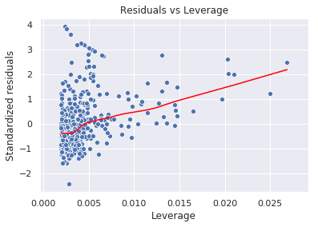

```python
plot_4_std_resid_vs_leverage(lm_fit);
```

```python
def plot_lm_summary(lm_fit,
                    title="Linear Model Summary (R-style)",
                    figsize=(15,10)):
    """Produce an R-style summary of a fitted linear model.
    The linear model must be the result of a StatsModel OLS."""
    fig, ax = plt.subplots(nrows=2,ncols=2, figsize=figsize)
    plot_1_resid_vs_fitted(lm_fit, ax=ax[0,0]);
    plot_2_residuals_vs_normal(lm_fit, ax=ax[0,1]);
    plot_3_std_resid_vs_fitted(lm_fit, ax=ax[1,0]);
    plot_4_std_resid_vs_leverage(lm_fit, ax=ax[1,1]);
    if title: fig.suptitle(title, fontsize=18)
    return fig
```

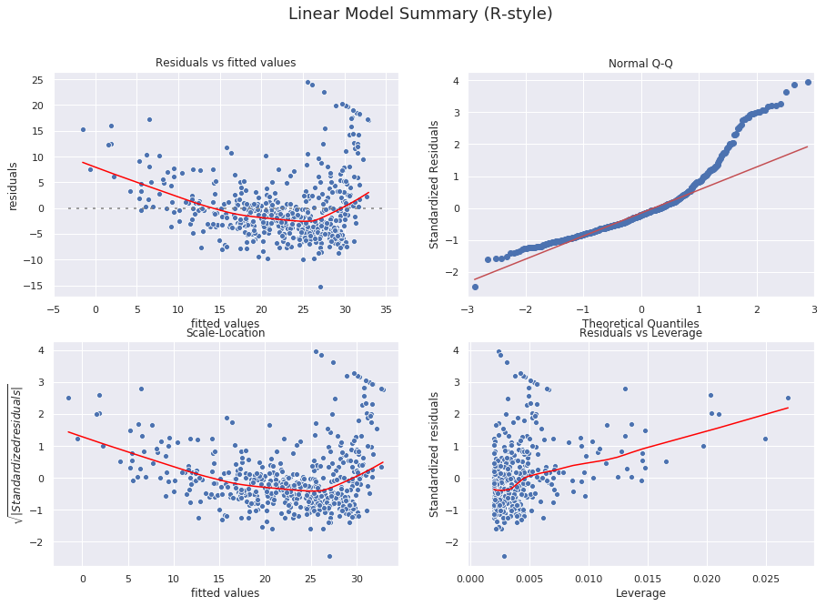

```python
plot_lm_summary(lm_fit);
```